# Chi Squared Test

## Background

“The General Social Survey (GSS) conducts basic scientific research on the structure and development of American society with a data-collection program designed to both monitor societal change within the United States and to compare the United States to other nations.”[$^1$](http://www3.norc.org/GSS+Website/)

This survey is given to random adults varying in age every couple of years and provides answers to many different questions.

## Hypothesis

We are going to be looking at the question as to whether gender is associated with the likelihood of getting a speeding ticket or traffic violation?

$$H_{0}:\ \text{Gender and having received a speeding ticket or traffic violation are not associated.}$$

$$H_{a}:\ \text{Gender and having received a speeding ticket or traffic violation are associated.}$$

For this analysis we will us the level of significance of $\alpha$ = 0.05

## Analysis

Looking at the table below we can see the actual counts of Male and Females who have reported receiving a speeding ticket or traffic.

```r
gss1 <- filter(GSS, ticket %in% c(1,2))
gss2 <- gss1 %>%
  mutate(sex = case_when(
    sex == 1 ~ "Male",
    sex == 2 ~ "Female")) %>%
  mutate(ticket = case_when(
    ticket == 1 ~ "Yes",
    ticket == 2 ~ "No"
  ))
ticket <- table(gss2$sex, gss2$ticket)

pander(ticket)
```

|  | No | Yes |
| --- | --- | --- |
| **Female** | 408 | 550 |
| **Male** | 229 | 562 |

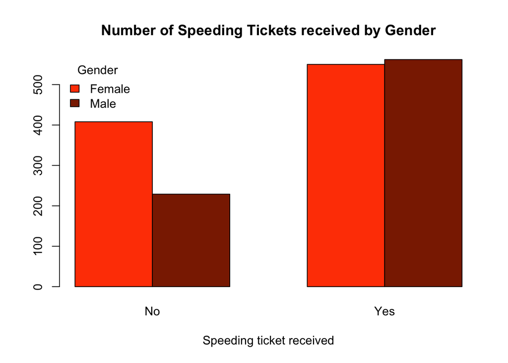

```r
barplot(ticket, beside=TRUE, col=c("orangered","orangered4"),legend.text=TRUE,args.legend = list(x="topleft",bty="n",title="Gender"),xlab="Speeding ticket received",main="Number of Speeding Tickets received by Gender")
```

From this barplot, we can clearly that those that reported ‘yes’ to having received a speeding ticket between the two genders is relatively the same. Those that reported ‘no’ to having received a speeding ticket has a noticeable diffence which we learn from the table to be 408 females to 229 males. Now to determine if their truly is an association between gender and getting a speeding ticket, we’ll run the chi-squared test:

```r
ticketchi <- chisq.test(ticket)
pander(ticketchi)
```

Pearson’s Chi-squared test with Yates’ continuity correction: `ticket`

| Test statistic | df | P value |
| --- | --- | --- |
| 34.21 | 1 | 4.936e-09 * * * |

According to the test above, the p-value at 4.936e-09 is less than 0.05. Before rejecting the null hypothesis, however, lets check if the requirements of the Chi-Squared test are satisfied. The following table shows expected counts.

```r
pander(ticketchi$expected)
```

|  | No | Yes |
| --- | --- | --- |
| **Female** | 348.9 | 609.1 |
| **Male** | 288.1 | 502.9 |

Since all expected counts are greater than 5, our requirements are met and we can reject the null hypothesis reasonably conclude that gender and receiving a speeding ticket are associated.

## Interpretation

This is an interesting test, we concluded that gender is associated with receiving a speeding ticket. We can clearly see that Women are less likely to receive a speeding ticket than men. This is very interesting, and raises the question, why? It would be fun to study more into other factors including, What is the average drive time of Men versus Women per month? What is the marital status of these individuals receiving the tickets? Are kids present in the car when tickets are given? etc..